# Capsula N°1

Thomas Riffo

2025-04-22

### *DISTRIBUCIONES*

Hay varias distribuciones en el mundo de las estadisticas, las distribuciones nos permiten identificar la probabilidad de que “tal evento ocurra”.

- **Geometrica**
- **Hipergeometrica**
- **Bernoulli**
- **Binomial**
- **Binomial negativa**
- **Poisson**

# Ejercicios:

Descargamos las librerías

### Ejercicio de distribución normal.

- **dnorm:** Calcula la densidad de una distribución normal.
- **pnorm:** Calcula la distribución acumulada.
- **qnorm:** Practicamente, encuentra un percentil.
- **rnorm:** Genera aleatoriamente n observaciones de la distribución normal

Se ha comprobado que el tiempo que tardan los contribuyentes en diligenciar el formulario para la declaración de renta sigue una distribución normal con media 100 minutos y desviación estándar 30 minutos.

Sabemos que nos entregan la media y la desviación estandar, además de que nos preguntan entre tantas, por lo cual:

```r
#Definimos las variables
mu = 100
sigma = 30

#Pero lo podemos hacer de otra forma, mucho más lindo
prob_70_130 <- pnorm(130, mean = 100, sd = 30) - pnorm(70, mean = 100, sd = 30)
prob_70_130
```

```
## [1] 0.6826895
```

Vamos a realizar una grafica para analizar lo que nos quieren decir.

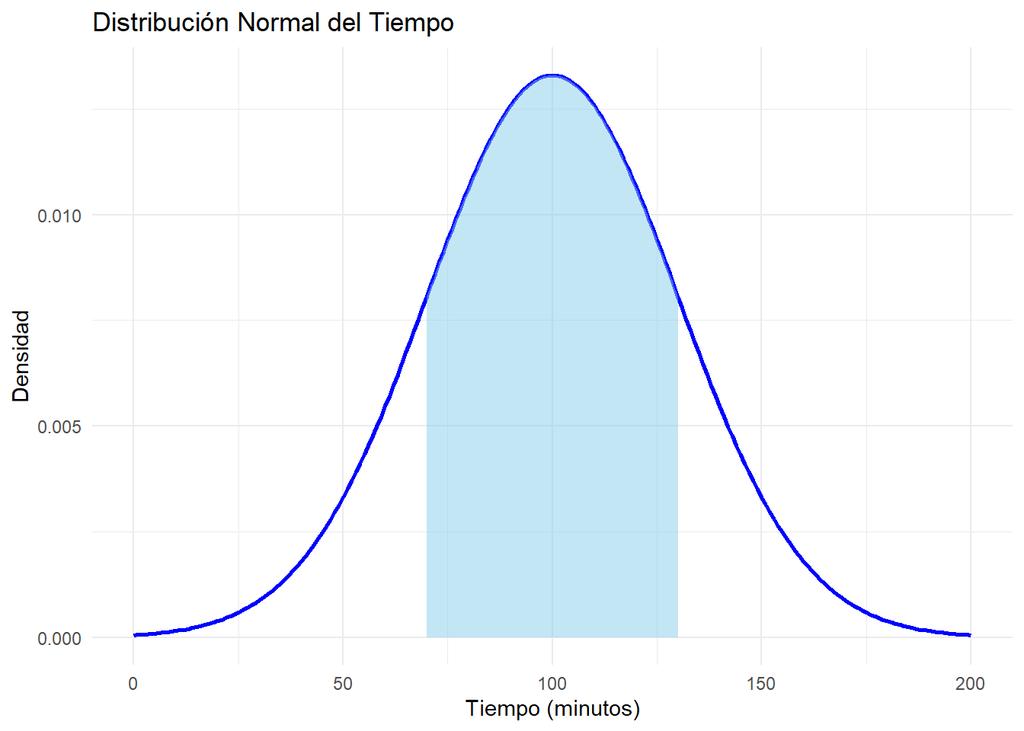

```r
library(ggplot2)

# Parametros del problema
mu = 100
sigma = 30

# Secuencia de valores X para graficar
x <- seq(0, 200, by = 1)
y <- dnorm(x, mean = mu, sd = sigma)

# Creamos el dataframe
df <- data.frame(x = x, y = y)

# Se crea la grafica
ggplot(df, aes(x, y)) +
  geom_line(color = "blue", size = 1) +
  geom_area(data = subset(df, x >= 70 & x <= 130), aes(x, y), fill = "skyblue", alpha = 0.5) +
  labs(
    title = "Distribución Normal del Tiempo",
    x = "Tiempo (minutos)",
    y = "Densidad"
  ) +
  theme_minimal()
```

Halle el valor de k tal que el 5% de los contribuyentes tarda más de k minutos en diligenciar el formulario.

```r
normal_percentil = qnorm(0.95, mean = mu, sd = sigma)
```

### Ejercicio de binomial.

Un abogado se traslada diariamente desde su casa (en los suburbios) a su oficina en el centro de la ciudad. En promedio, el viaje le toma 24 minutos con una desviación estándar de 3.8 minutos. Asuma que la distribución de los tiempos de traslado está normalmente distribuida.

Si la oficina abre a las 9:00 a.m y él sale de su casa a las 8:45 a.m diariamente, ¿qué porcentaje de las veces llega tarde a su trabajo?

```r
#Parámetros del problema
mu <- 24
sigma <- 3.8

#Probabilidad de llegar tarde
p_llega_tarde <- 1 - pnorm(15, mean = mu, sd = sigma)
round(p_llega_tarde, 4)
```

```
## [1] 0.9911
```

Si deja su casa a las 8:35 a.m y en la oficina se sirve un café entre las 8:50 y las 9:00 a.m, ¿cuál es la probabilidad de que le sirvan el café?

```r
#En este caso sería esto porque tenemos que tener en cuenta que hay "entre medio"
p_cafe <- pnorm(25, mean = mu, sd = sigma) - pnorm(15, mean = mu, sd = sigma)
round(p_cafe, 4)
```

```
## [1] 0.5949
```

Encuentre el periodo por encima del cual se encuentra el 15% de los traslados más lentos.

```r
#Aquí usamos los qnorm ya que trabajamos con percentiles.
k_lento <- qnorm(0.85, mean = mu, sd = sigma)
round(k_lento, 2)
```

```
## [1] 27.94
```

Suponga que se toma una muestra de 5 viajes que ha realizado el abogado. Si el abogado siempre sale de su casa a las 8:30 a.m, calcule la probabilidad de que en al menos 2 viajes haya llegado entre las 9:05 a.m. y 9:20 a.m.

```r
#Probabilidad de un viaje entre 35 y 50 minutos
p_lento_intervalo <- pnorm(50, mean = mu, sd = sigma) - pnorm(35, mean = mu, sd = sigma)

#Probabilidad binomial de al menos 2
p_binomial <- 1 - dbinom(0, size = 5, prob = p_lento_intervalo) - dbinom(1, size = 5, prob = p_lento_intervalo)
round(p_binomial, 4)
```

```
## [1] 0
```

### Ejercicio de Poisson

Formula de Poisson: Como es LaTex, se pueden escribir así las formulas (hay que saberse las notaciones)
$$P(X = k) = \frac{\lambda^k e^{-\lambda}}{k!}$$

Un centro de llamadas recibe en promedio 4 llamadas por hora. Suponiendo que las llamadas llegan de manera aleatoria y que el número de llamadas por hora sigue una distribución de Poisson, contesta las siguientes preguntas:

¿Cuál es la probabilidad de que el centro de llamadas reciba exactamente 5 llamadas en una hora?

```r
#Definimos las variables
lambda = 4
observaciones = 5

#Conseguimos la probabilidad
poisson = dpois(x = 5, lambda = 4)
print(poisson)
```

```
## [1] 0.1562935
```

[figure not shown]

```r
library(ggplot2)

# Posibles valores que pueden existir
x = 0:30

# Distribución
y = dpois(x, lambda = 4)

# Creamos el Data frame
df = data.frame(x = x, y = y)




#--------------- Creamos la grafica -----------------------
ggplot(df, aes(x = factor(x), y = y)) +
  geom_col(fill = "red", color = "black") +
  geom_col(data = subset(df, x == 5), aes(x, y), fill = "blue", color = "black") +
  labs(
    title = "Distribución de Poisson: Llamadas por Hora",
    x = "Número de llamadas en una hora",
    y = "Probabilidad"
  ) +
  theme_minimal()
```

¿Cuál es la probabilidad de que el centro de llamadas reciba 2 o menos llamadas en una hora?

```r
poisson_acumulado_menos = ppois(q = 2, lambda = 4)
poisson_acumulado_menos
```

```
## [1] 0.2381033
```

```r
poisson_acumulado_mas = 1 - ppois(q = 2, lambda = 4)
poisson_acumulado_mas
```

```
## [1] 0.7618967
```